# R 중급 통계분석 3일차 (1)

```
최소제곱법를 사용하는 선형모형은 가장 오래된 통계방법의 하나로, 이해하기 쉽기 떄문에 현재에도 널리 쓰이고 있는 방법이다. 이번 장에서는 내가 만든 회귀모형이 과연 적절한 것인가 하는 내용을 다룬다. 또한 다중 회귀분석에서 모형선택을 자동화 할수 있는 여러 방법 들을 다룬다. 이번 장의 대부분은 Robert I Kabacoff의 "R in action"(2nd edition)을 참고하여 기술하였음을 밝힌다.
```

## 회귀진단 : 회귀모형이 과연 적절한가?

최소제곱법를 사용하는 선형모형은 가장 오래된 통계방법의 하나이다. 고성능 컴퓨터를 어디에서나 사용할 수 있고 R과 같은 고성능의 통계 소프트웨어를 무료로 사용할 수 있으며 통계학자들이 수천 개의 새로운 통계방법을 개발해내는 요즘 시대에서도 선형회귀가 널리 쓰이는 이유는, 무엇보다 선형모형이 이해하기 쉬우며 또한 최소제곱법이 모든 선형 추정 방법들 중 가장 적은 분산을 보이기 때문이다. lm() 함수를 통해 OLS 회귀모형을 만들고 summary() 함수로 모형의 회귀계수 및 통계 수치를 볼 수 있지만 과연 이 모형이 적절한 것인지 검증이 필요하다.

회귀모형의 검증이 왜 필요한가? 데이터가 불규칙하거나 예측변수와 반응변수 사이의 관계를 잘못 설정한 경우 부정확한 통계 모형을 만들 수 있다. 바꿔 얘기하면 실제로 예측변수와 반응변수 사이에 관계가 있음에도 불구하고 관계가 없다고 결론내리거나 예측변수와 반응변수 사이에 아무런 관계가 없음에도 불구하고 관계가 있다고 결론을 내려 통계 모형을 만들지만 실제 real-world에 그 모형을 적용해보면 예측이 빗나가 불필요한 심각한 오류를 만들 수 있다.

예를 들어 미국의 50개주의 문맹률과 수입, 인구수, 결빙일, 살인사건 발생률에 관한 데이터를 분석해보자.

```r
states <- as.data.frame(state.x77[,c("Murder", "Population",
                             "Illiteracy", "Income", "Frost")])
head(states)
```

```
##            Murder Population Illiteracy Income Frost
## Alabama      15.1       3615        2.1   3624    20
## Alaska       11.3        365        1.5   6315   152
## Arizona       7.8       2212        1.8   4530    15
## Arkansas     10.1       2110        1.9   3378    65
## California   10.3      21198        1.1   5114    20
## Colorado      6.8       2541        0.7   4884   166
```

```r
fit=lm(Murder~Population+Illiteracy+Income+Frost,data=states)
summary(fit)
```

```
##
## Call:
## lm(formula = Murder ~ Population + Illiteracy + Income + Frost,
##     data = states)
##
## Residuals:
##     Min      1Q  Median      3Q     Max
## -4.7960 -1.6495 -0.0811  1.4815  7.6210
##
## Coefficients:
##              Estimate Std. Error t value Pr(>|t|)
## (Intercept) 1.235e+00  3.866e+00   0.319   0.7510
## Population  2.237e-04  9.052e-05   2.471   0.0173 *
## Illiteracy  4.143e+00  8.744e-01   4.738 2.19e-05 ***
## Income      6.442e-05  6.837e-04   0.094   0.9253
## Frost       5.813e-04  1.005e-02   0.058   0.9541
## ---
## Signif. codes:  0 '***' 0.001 '**' 0.01 '*' 0.05 '.' 0.1 ' ' 1
##
## Residual standard error: 2.535 on 45 degrees of freedom
## Multiple R-squared:  0.567,  Adjusted R-squared:  0.5285
## F-statistic: 14.73 on 4 and 45 DF,  p-value: 9.133e-08
```

```r
confint(fit)
```

```
##                     2.5 %       97.5 %
## (Intercept) -6.552191e+00 9.0213182149
## Population   4.136397e-05 0.0004059867
## Illiteracy   2.381799e+00 5.9038743192
## Income      -1.312611e-03 0.0014414600
## Frost       -1.966781e-02 0.0208304170
```

이 결과에서 문맹률(Illiteracy)이 1% 변하면 인구 10만 명당 살인사건 발생률이 4.14(2.38에서 5.90) 변화한다고 95%의 확신을 가지고 이야기 할 수 있으며, 1 년중 기온이 0도 이하로 떨어지는 Frost의 경우 95% 신뢰구간이 0을 지나므로 다른 변수들이 일정하다면 온도의 변화는 살인사건의 발생률과 관계가 없다고 결론내릴 수 있다. 하지만 이러한 통계적 추론에 대해 확신을 가지려면 데이터가 OLS 회귀의 가정을 만족해야만 한다.

[output not shown]

```r
library(car)
```

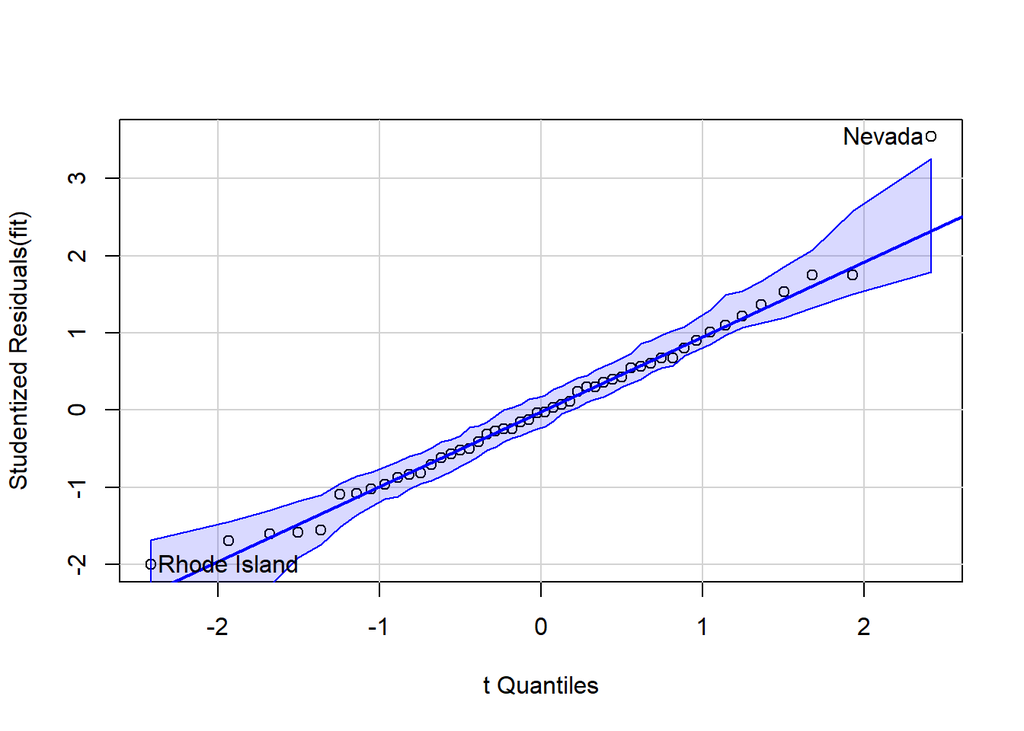

```
##       Nevada Rhode Island
##           28           39
```

```r
# 정규성
qqPlot(fit)
```

```r
shapiro.test(fit$residuals)
```

```
##
##  Shapiro-Wilk normality test
##
## data:  fit$residuals
## W = 0.98264, p-value = 0.6672
```

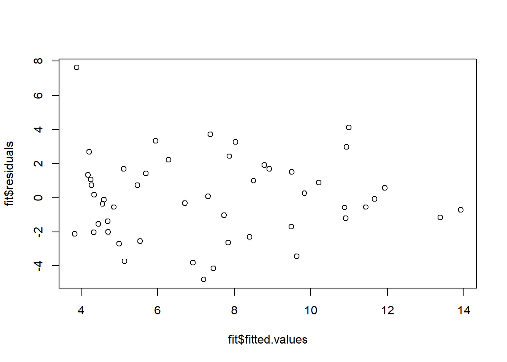

```r
# 독립성
plot(fit$fitted.values, fit$residuals)
```

```r
durbinWatsonTest(fit)
```

```
##  lag Autocorrelation D-W Statistic p-value
##    1      -0.2006929      2.317691   0.284
##  Alternative hypothesis: rho != 0
```

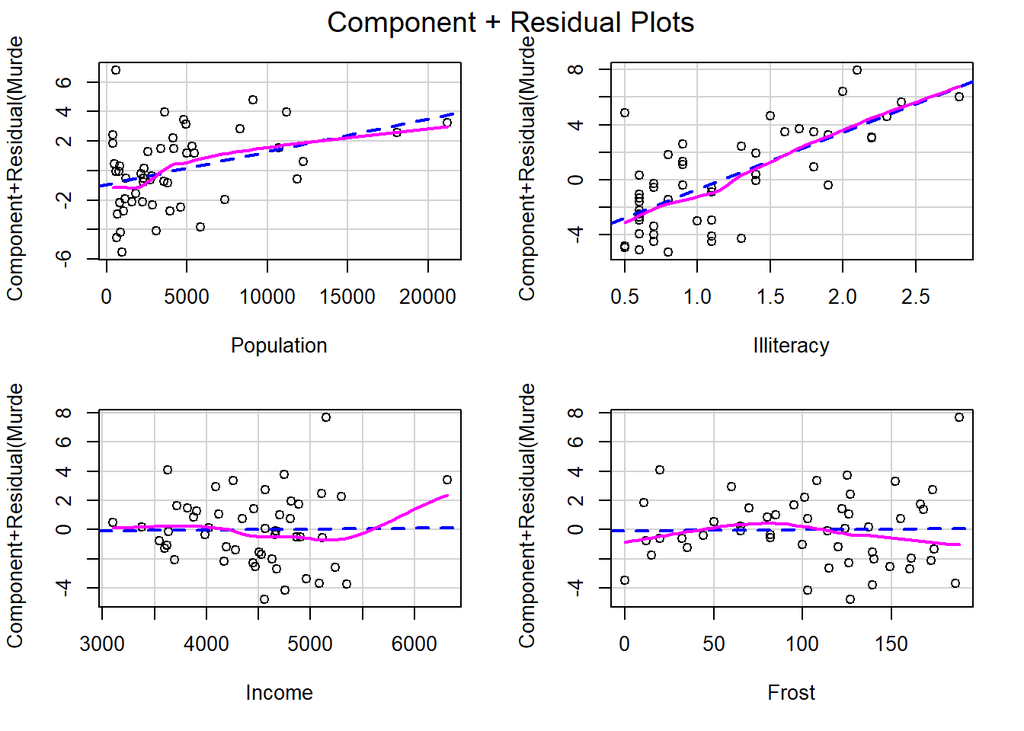

```r
# 선형형
crPlots(fit)
```

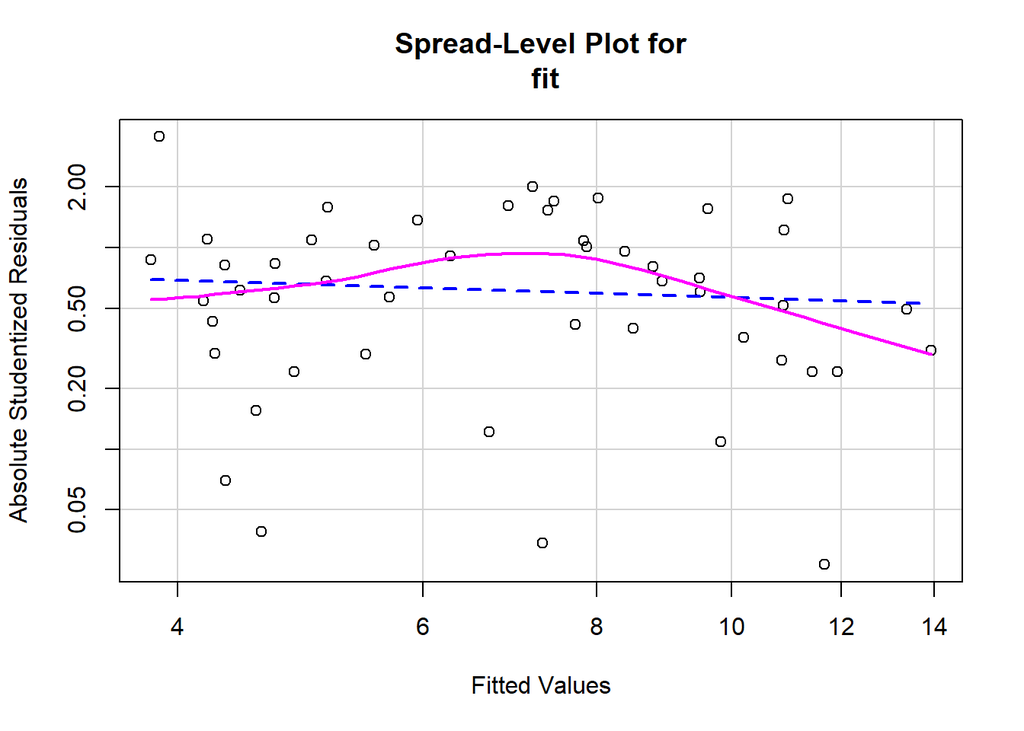

```
##
## Suggested power transformation:  1.209626
```

```r
# 등분산성
spreadLevelPlot(fit)
```

```r
ncvTest(fit)
```

```
## Non-constant Variance Score Test
## Variance formula: ~ fitted.values
## Chisquare = 1.746514, Df = 1, p = 0.18632
```

### 다중공선성?

다중회귀를 할 때 고려해야 할 것 중에 하나는 다중공선성이다. 이것은 통계의 가정과는 관계없지만 다중회귀 결과를 해석할 때 중요하다. 예를 들어 손의 악력에 대한 연구를 할때 반응변수(종속변수)를 손의 악력으로 하고 예측변수(독립변수)로 태어난 날짜(DOB)와 나이를 넣었다고 해보자. 악력과 DOB, 나이를 전체적으로 보면 F 검정 결과 p값이 0.001 이하로 유의하게 나오지만 DOB와 나이에 대한 회귀계수를 각각 살펴보면 모두 유의하지 않게 나온다. 왜 그럴까?

생년월일과 나이는 완전한 상관관계를 이룬다. 다중회귀분석에서 회귀계수를 구할 때 다른 변수들이 일정할 때 한 예측변수가 반응변수에 미치는 영향을 측정한다. 따라서 악력을 종속변수로 생년원일과 나이를 독립변수로 넣고 다중회귀를 하는 것은 나이가 일정할 때 나이에 따른 악력의 변화를 보는 것과 같다. 이런 문제를 다중공선성이라고 한다. 이 때 통계모형의 계수들에 대한 신뢰구간이 커지기 때문에 각각의 회귀계수에 대한 해석을 어렵게 만든다.

다중공선성은 분산팽창지수(variation inflation factor, VIF)라는 통계량을 사용하여 계산할 수 있다.

```r
vif(fit)
```

```
## Population Illiteracy     Income      Frost
##   1.245282   2.165848   1.345822   2.082547
```

```r
vif(fit)>5
```

```
## Population Illiteracy     Income      Frost
##      FALSE      FALSE      FALSE      FALSE
```

### 영향력 분석

큰지레점 : 큰지레점은 hat 통계량으로 알 수 있다.

이상치 : car패키지의 outlierTest() 함수를 사용하여 outlier를 찾아낼수 있다.

영향관측치 : 영향관측치는 모형의 인수들에 불균형한 영향을 미치는 관측치이다. 하나의 관측치를 제거함으로써 모형이 극적으로 달라지게 되는 경우가 있는데 이러한 관측치가 영향관측치이다. 영향관측치를 찾아내는 방법은 Cook’s distance 또는 D statistics를 이용하는 방법이 있다.

```r
hatvalues(fit)
```

```
##        Alabama         Alaska        Arizona       Arkansas     California
##     0.09819211     0.43247319     0.12264914     0.08722029     0.34087628
##       Colorado    Connecticut       Delaware        Florida        Georgia
##     0.05469964     0.09474658     0.05859637     0.12940379     0.05803142
##         Hawaii          Idaho       Illinois        Indiana           Iowa
##     0.22443594     0.06905425     0.09683616     0.03871740     0.04627447
##         Kansas       Kentucky      Louisiana          Maine       Maryland
##     0.05245106     0.05131253     0.17022388     0.09966458     0.06942663
##  Massachusetts       Michigan      Minnesota    Mississippi       Missouri
##     0.02687166     0.05740920     0.04638897     0.14748152     0.04199088
##        Montana       Nebraska         Nevada  New Hampshire     New Jersey
##     0.05253317     0.04421328     0.09508977     0.06387335     0.06616617
##     New Mexico       New York North Carolina   North Dakota           Ohio
##     0.15998871     0.23298637     0.05218913     0.10529028     0.08652446
##       Oklahoma         Oregon   Pennsylvania   Rhode Island South Carolina
##     0.05117056     0.19057634     0.11185698     0.04562377     0.10445404
##   South Dakota      Tennessee          Texas           Utah        Vermont
##     0.07553161     0.04580225     0.13392638     0.06970746     0.08788063
##       Virginia     Washington  West Virginia      Wisconsin        Wyoming
##     0.03230467     0.21662901     0.05839687     0.04173326     0.06012359
```

```r
outlierTest(fit)
```

```
##        rstudent unadjusted p-value Bonferroni p
## Nevada 3.542929         0.00095088     0.047544
```

```r
dffits(fit)
```

```
##        Alabama         Alaska        Arizona       Arkansas     California
##    0.576318803    1.530874671   -0.264165595    0.033662356   -0.198590631
##       Colorado    Connecticut       Delaware        Florida        Georgia
##    0.163563900   -0.520029220    0.074065418    0.310401782    0.302076343
##         Hawaii          Idaho       Illinois        Indiana           Iowa
##   -0.836982730    0.116879704    0.330288688    0.113709358   -0.179546396
##         Kansas       Kentucky      Louisiana          Maine       Maryland
##   -0.009174987    0.157755340   -0.140027500   -0.276071219    0.246883948
##  Massachusetts       Michigan      Minnesota    Mississippi       Missouri
##   -0.282046618    0.378621619   -0.240304351    0.100287400    0.285182381
##        Montana       Nebraska         Nevada  New Hampshire     New Jersey
##    0.070156067   -0.132453015    1.148488241   -0.147241059   -0.286965482
##     New Mexico       New York North Carolina   North Dakota           Ohio
##   -0.224761375   -0.132948759    0.084286517   -0.542034202    0.010562616
##       Oklahoma         Oregon   Pennsylvania   Rhode Island South Carolina
##   -0.028204790   -0.075113770   -0.339881405   -0.437321852   -0.009140058
##   South Dakota      Tennessee          Texas           Utah        Vermont
##   -0.248739902    0.131981834   -0.194387335    0.019031239    0.168517353
##       Virginia     Washington  West Virginia      Wisconsin        Wyoming
##    0.072513088   -0.127157205   -0.103121871   -0.213334105    0.278625416
```

```r
k = length(fit$coefficients)
2*sqrt(k+1/(nrow(states)-k-1))
```

```
## [1] 4.482288
```

```r
abs(dffits(fit))>2*sqrt(k+1/(nrow(states)-k-1))
```

```
##        Alabama         Alaska        Arizona       Arkansas     California
##          FALSE          FALSE          FALSE          FALSE          FALSE
##       Colorado    Connecticut       Delaware        Florida        Georgia
##          FALSE          FALSE          FALSE          FALSE          FALSE
##         Hawaii          Idaho       Illinois        Indiana           Iowa
##          FALSE          FALSE          FALSE          FALSE          FALSE
##         Kansas       Kentucky      Louisiana          Maine       Maryland
##          FALSE          FALSE          FALSE          FALSE          FALSE
##  Massachusetts       Michigan      Minnesota    Mississippi       Missouri
##          FALSE          FALSE          FALSE          FALSE          FALSE
##        Montana       Nebraska         Nevada  New Hampshire     New Jersey
##          FALSE          FALSE          FALSE          FALSE          FALSE
##     New Mexico       New York North Carolina   North Dakota           Ohio
##          FALSE          FALSE          FALSE          FALSE          FALSE
##       Oklahoma         Oregon   Pennsylvania   Rhode Island South Carolina
##          FALSE          FALSE          FALSE          FALSE          FALSE
##   South Dakota      Tennessee          Texas           Utah        Vermont
##          FALSE          FALSE          FALSE          FALSE          FALSE
##       Virginia     Washington  West Virginia      Wisconsin        Wyoming
##          FALSE          FALSE          FALSE          FALSE          FALSE
```

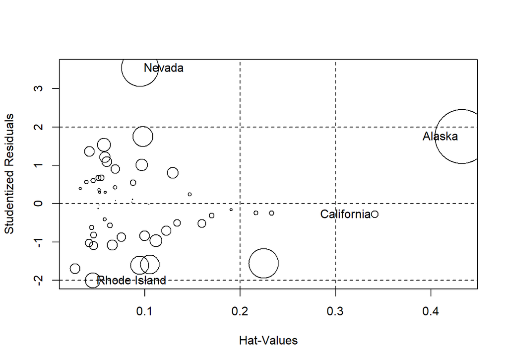

```
##                 StudRes        Hat       CookD
## Alaska        1.7536917 0.43247319 0.448050997
## California   -0.2761492 0.34087628 0.008052956
## Nevada        3.5429286 0.09508977 0.209915743
## Rhode Island -2.0001631 0.04562377 0.035858963
```

```r
influencePlot(fit)
```

그래프의 y축이 표준화된 잔차이므로 2배 이상 벌어져 있는 Nevada와 Rhode Island는 이상치이다. x축이 hat 값이므로 평균 hat 값의 2배 이상 되는 Hawaii, Washington, NewYork, California, Alaska가 큰지레점이며 원의 크기가 Cook’s D 값을 반영하므로 원의 크기가 큰 Alaska, Navada, Hawaii가 영향관측치라고 할 수 있다.

```r
which(abs(rstudent(fit))>2)
```

```
##       Nevada Rhode Island
##           28           39
```

```r
newdata <- states[-which(abs(rstudent(fit))>2),]

fit=lm(Murder~Population+Illiteracy+Income+Frost,data=newdata)
summary(fit)
```

```
##
## Call:
## lm(formula = Murder ~ Population + Illiteracy + Income + Frost,
##     data = newdata)
##
## Residuals:
##     Min      1Q  Median      3Q     Max
## -4.0324 -1.5603 -0.1852  1.5471  3.9121
##
## Coefficients:
##               Estimate Std. Error t value Pr(>|t|)
## (Intercept)  2.347e+00  3.381e+00   0.694  0.49136
## Population   2.318e-04  7.861e-05   2.949  0.00514 **
## Illiteracy   4.195e+00  7.582e-01   5.533 1.74e-06 ***
## Income      -1.494e-04  5.976e-04  -0.250  0.80372
## Frost       -2.578e-03  8.782e-03  -0.294  0.77049
## ---
## Signif. codes:  0 '***' 0.001 '**' 0.01 '*' 0.05 '.' 0.1 ' ' 1
##
## Residual standard error: 2.182 on 43 degrees of freedom
## Multiple R-squared:  0.6729, Adjusted R-squared:  0.6424
## F-statistic: 22.11 on 4 and 43 DF,  p-value: 5.707e-10
```

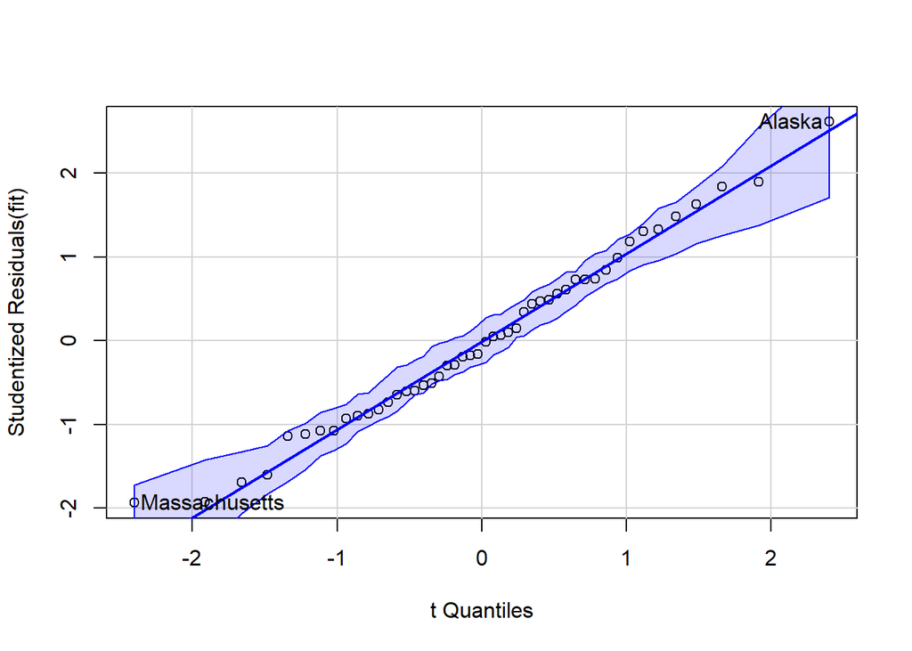

```
##        Alaska Massachusetts
##             2            21
```

```r
# 정규성
qqPlot(fit)
```

```r
shapiro.test(fit$residuals)
```

```
##
##  Shapiro-Wilk normality test
##
## data:  fit$residuals
## W = 0.97721, p-value = 0.4683
```

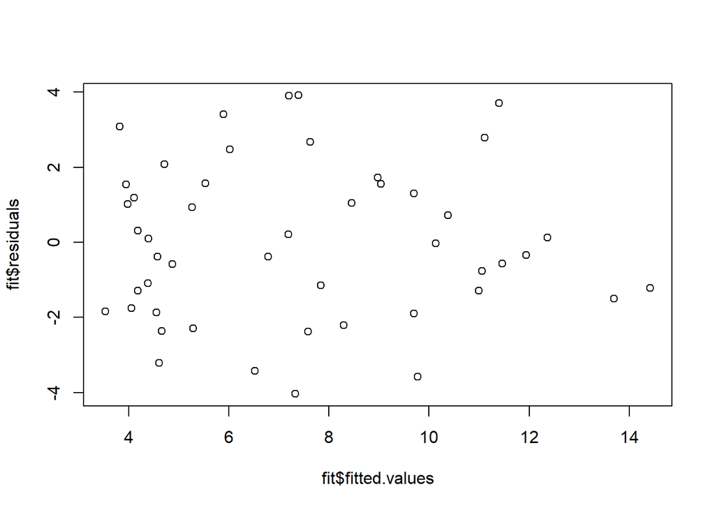

```r
# 독립성
plot(fit$fitted.values, fit$residuals)
```

```r
durbinWatsonTest(fit)
```

```
##  lag Autocorrelation D-W Statistic p-value
##    1      -0.2211193      2.329156   0.248
##  Alternative hypothesis: rho != 0
```

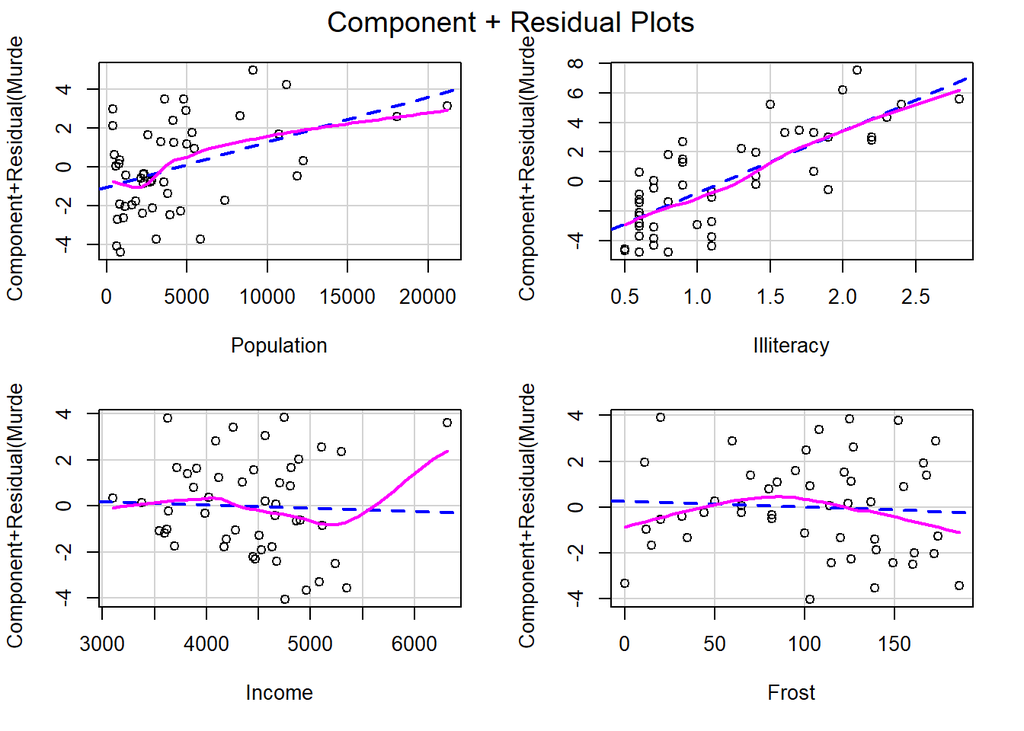

```r
# 선형형
crPlots(fit)
```

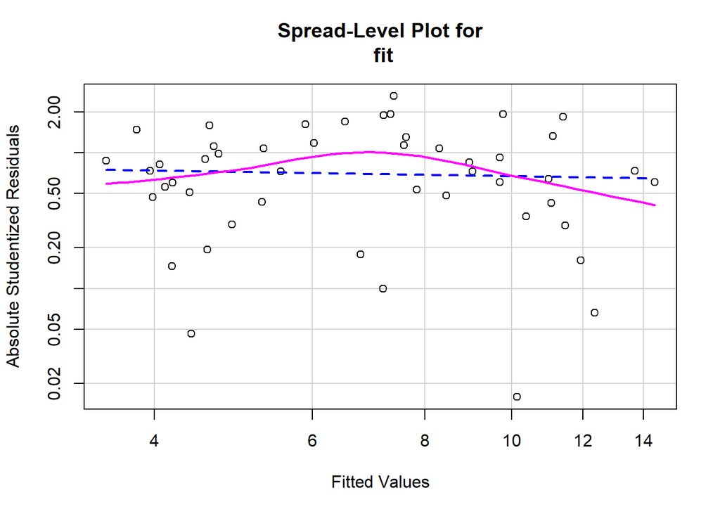

```
##
## Suggested power transformation:  1.103759
```

```r
# 등분산성
spreadLevelPlot(fit)
```

```r
ncvTest(fit)
```

```
## Non-constant Variance Score Test
## Variance formula: ~ fitted.values
## Chisquare = 0.04849758, Df = 1, p = 0.8257
```

```r
outlierTest(fit)
```

```
## No Studentized residuals with Bonferroni p < 0.05
## Largest |rstudent|:
##        rstudent unadjusted p-value Bonferroni p
## Alaska 2.611353           0.012453      0.59774
```

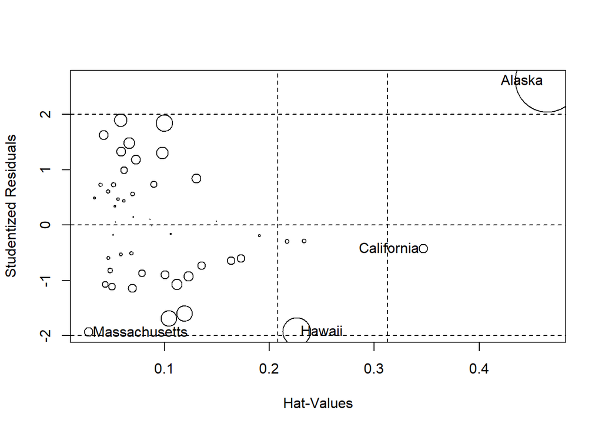

```
##                  StudRes        Hat      CookD
## Alaska         2.6113525 0.46496719 1.04395320
## California    -0.4259426 0.34681511 0.01963999
## Hawaii        -1.9200620 0.22596150 0.20258703
## Massachusetts -1.9329805 0.02803647 0.02026584
```

```r
influencePlot(fit)
```

“Nevada”와 “Rhode Island”를 제거한 자료에 대해 다시 모형을 진단한 결과 Alaska가 좋지 못함.

```r
which(abs(rstudent(fit))>2)
```

```
## Alaska
##      2
```

```r
newdata2 <- newdata[-which(abs(rstudent(fit))>2),]

fit=lm(Murder~Population+Illiteracy+Income+Frost,data=newdata2)
summary(fit)
```

```
##
## Call:
## lm(formula = Murder ~ Population + Illiteracy + Income + Frost,
##     data = newdata2)
##
## Residuals:
##     Min      1Q  Median      3Q     Max
## -3.6380 -1.4465 -0.4951  1.3205  4.0302
##
## Coefficients:
##               Estimate Std. Error t value Pr(>|t|)
## (Intercept)  9.319e+00  4.147e+00   2.247 0.029941 *
## Population   2.914e-04  7.722e-05   3.773 0.000499 ***
## Illiteracy   3.109e+00  8.242e-01   3.772 0.000501 ***
## Income      -1.367e-03  7.293e-04  -1.874 0.067877 .
## Frost       -9.663e-03  8.677e-03  -1.114 0.271770
## ---
## Signif. codes:  0 '***' 0.001 '**' 0.01 '*' 0.05 '.' 0.1 ' ' 1
##
## Residual standard error: 2.048 on 42 degrees of freedom
## Multiple R-squared:  0.7114, Adjusted R-squared:  0.6839
## F-statistic: 25.88 on 4 and 42 DF,  p-value: 7.407e-11
```

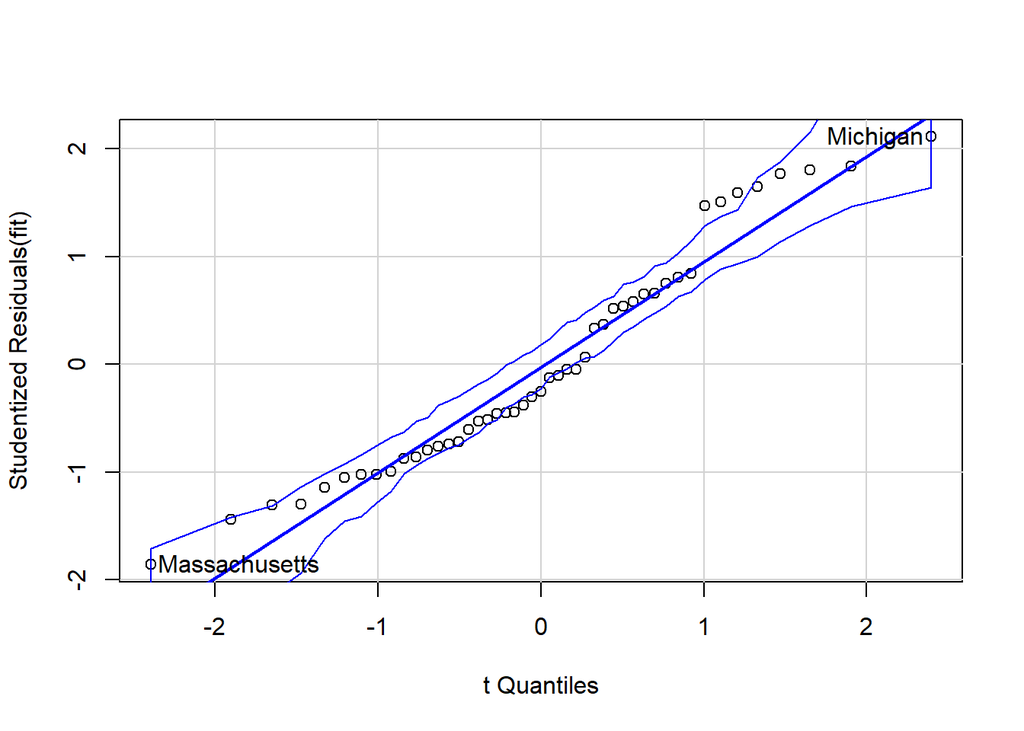

```
## Massachusetts      Michigan
##            20            21
```

```r
# 정규성
qqPlot(fit)
```

```r
shapiro.test(fit$residuals)
```

```
##
##  Shapiro-Wilk normality test
##
## data:  fit$residuals
## W = 0.94641, p-value = 0.03138
```

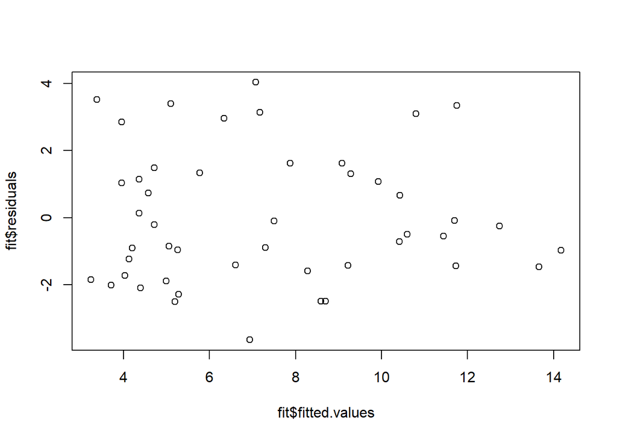

```r
# 독립성
plot(fit$fitted.values, fit$residuals)
```

```r
durbinWatsonTest(fit)
```

```
##  lag Autocorrelation D-W Statistic p-value
##    1      -0.3145654      2.495297   0.078
##  Alternative hypothesis: rho != 0
```

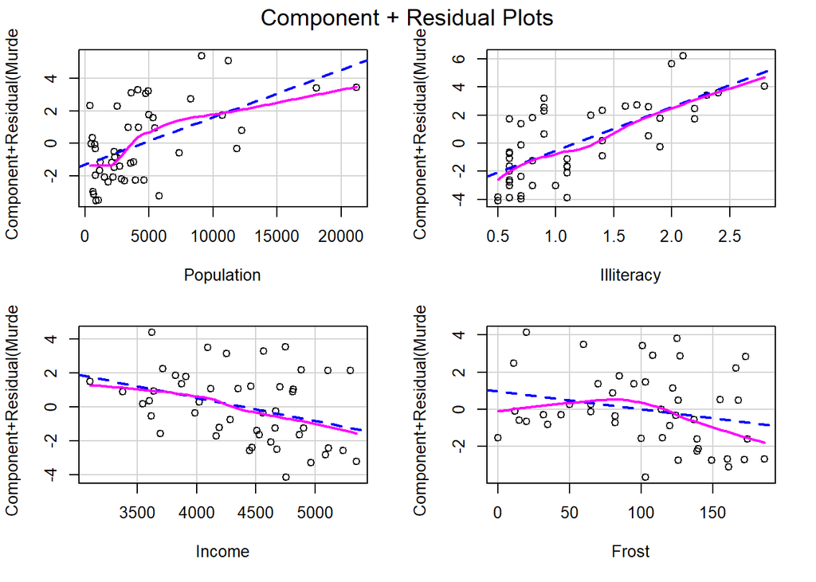

```r
# 선형형
crPlots(fit)
```

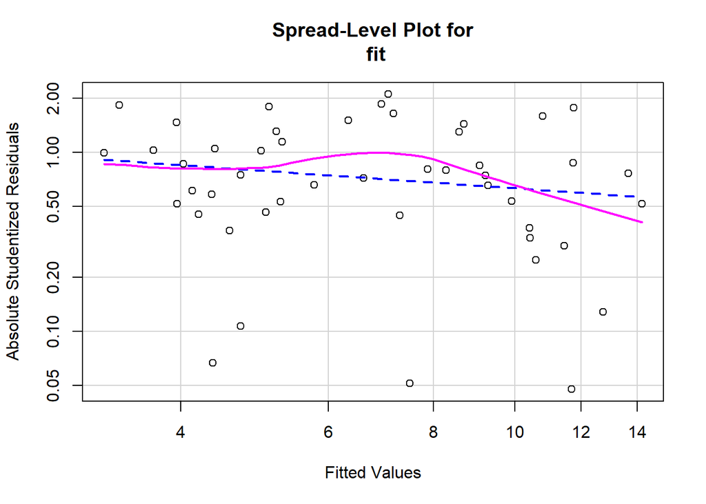

```
##
## Suggested power transformation:  1.326023
```

```r
# 등분산성
spreadLevelPlot(fit)
```

```r
ncvTest(fit)
```

```
## Non-constant Variance Score Test
## Variance formula: ~ fitted.values
## Chisquare = 0.5272819, Df = 1, p = 0.46775
```

```r
outlierTest(fit)
```

```
## No Studentized residuals with Bonferroni p < 0.05
## Largest |rstudent|:
##          rstudent unadjusted p-value Bonferroni p
## Michigan 2.110068           0.040999           NA
```

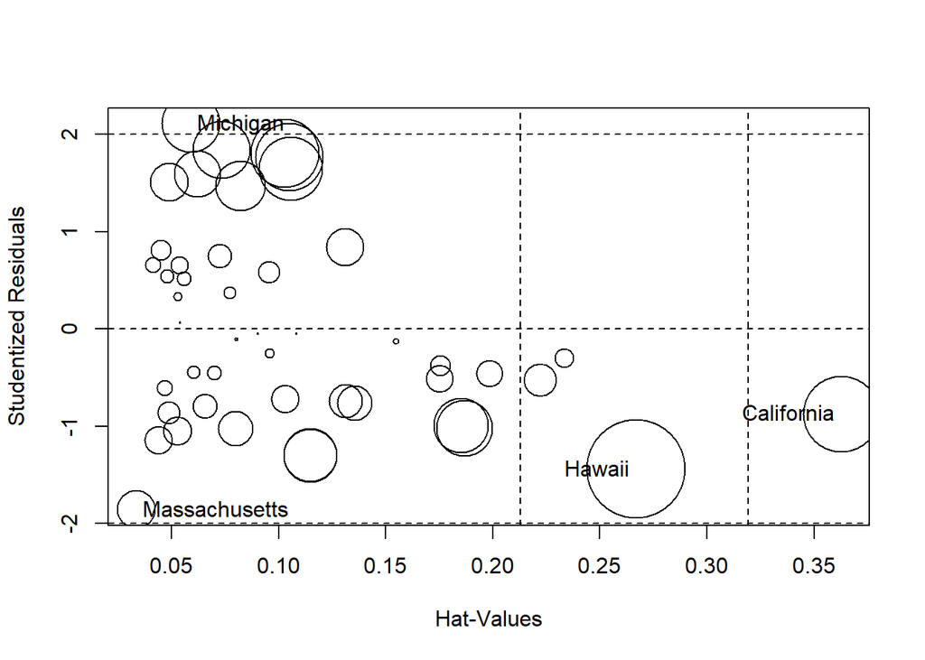

```
##                  StudRes        Hat      CookD
## California    -0.8731788 0.36266175 0.08726328
## Hawaii        -1.4408429 0.26684463 0.14734634
## Massachusetts -1.8588495 0.03347508 0.02261271
## Michigan       2.1100683 0.05881181 0.05141664
```

```r
influencePlot(fit)
```

새로운 자료에 대한 분석 결과 Michigan이 제외 됨

```r
which(abs(rstudent(fit))>2)
```

```
## Michigan
##       21
```

```r
newdata3 <- newdata2[-which(abs(rstudent(fit))>2),]

fit=lm(Murder~Population+Illiteracy+Income+Frost,data=newdata3)
summary(fit)
```

```
##
## Call:
## lm(formula = Murder ~ Population + Illiteracy + Income + Frost,
##     data = newdata3)
##
## Residuals:
##     Min      1Q  Median      3Q     Max
## -3.4993 -1.4476 -0.4232  1.3170  3.6172
##
## Coefficients:
##               Estimate Std. Error t value Pr(>|t|)
## (Intercept)  9.679e+00  3.990e+00   2.426 0.019761 *
## Population   2.664e-04  7.517e-05   3.545 0.000999 ***
## Illiteracy   3.087e+00  7.923e-01   3.896 0.000354 ***
## Income      -1.401e-03  7.012e-04  -1.998 0.052340 .
## Frost       -1.127e-02  8.376e-03  -1.346 0.185798
## ---
## Signif. codes:  0 '***' 0.001 '**' 0.01 '*' 0.05 '.' 0.1 ' ' 1
##
## Residual standard error: 1.969 on 41 degrees of freedom
## Multiple R-squared:  0.7332, Adjusted R-squared:  0.7072
## F-statistic: 28.17 on 4 and 41 DF,  p-value: 2.757e-11
```

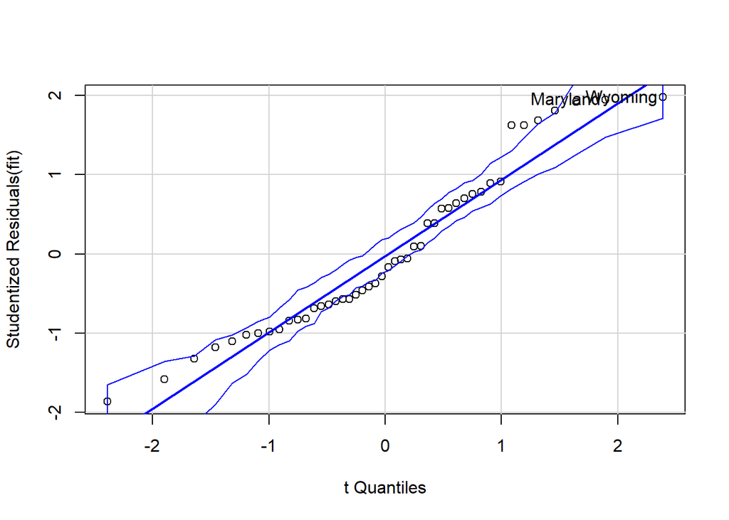

```
## Maryland  Wyoming
##       19       46
```

```r
# 정규성
qqPlot(fit)
```

```r
shapiro.test(fit$residuals)
```

```
##
##  Shapiro-Wilk normality test
##
## data:  fit$residuals
## W = 0.94358, p-value = 0.02667
```

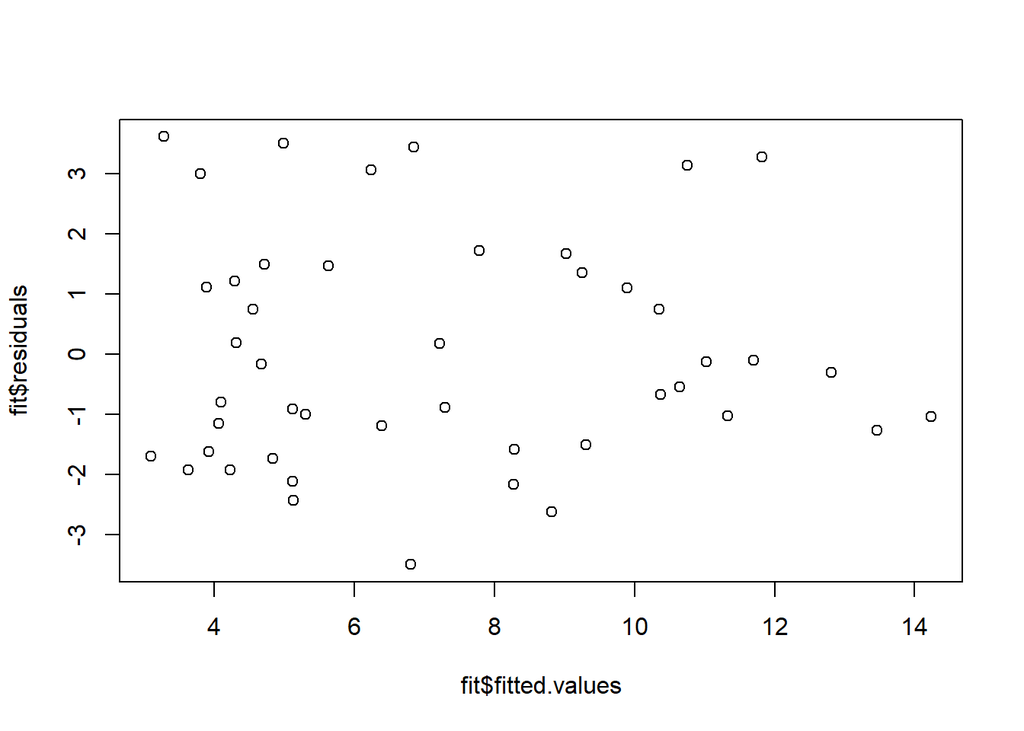

```r
# 독립성
plot(fit$fitted.values, fit$residuals)
```

```r
durbinWatsonTest(fit)
```

```
##  lag Autocorrelation D-W Statistic p-value
##    1      -0.1550589      2.160123   0.608
##  Alternative hypothesis: rho != 0
```

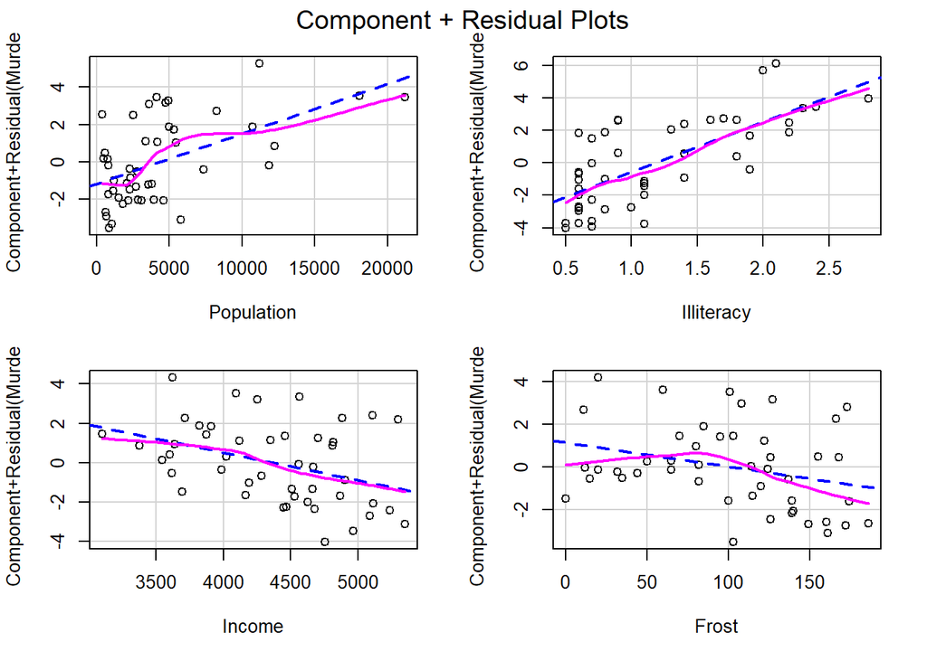

```r
# 선형형
crPlots(fit)
```

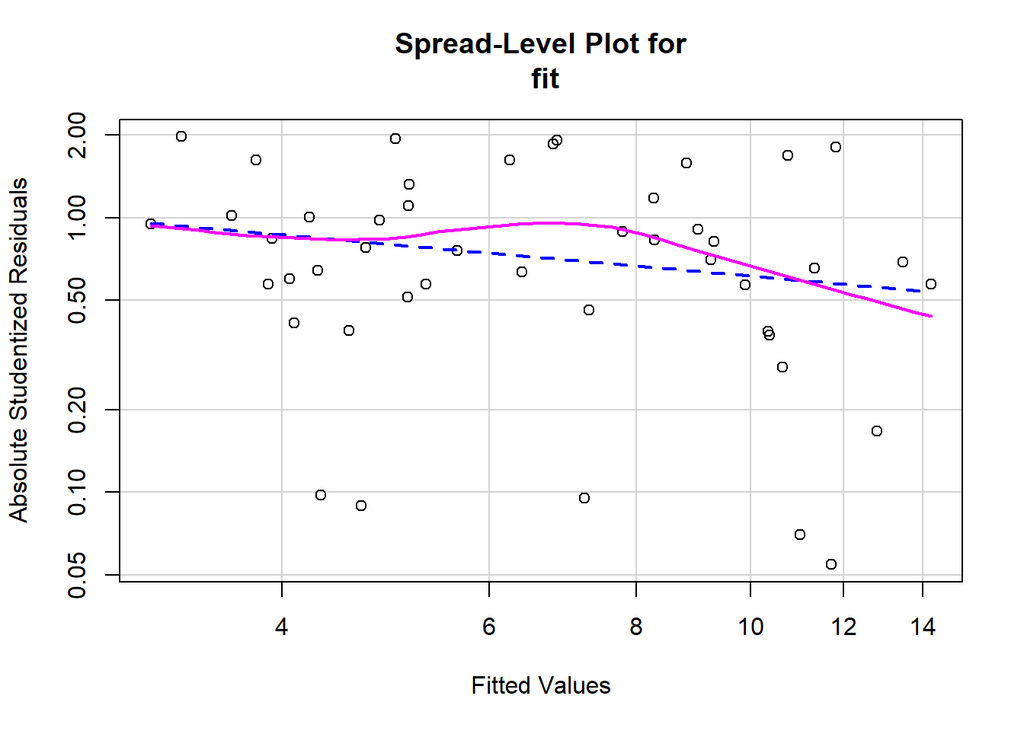

```
##
## Suggested power transformation:  1.376847
```

```r
# 등분산성
spreadLevelPlot(fit)
```

```r
ncvTest(fit)
```

```
## Non-constant Variance Score Test
## Variance formula: ~ fitted.values
## Chisquare = 0.706349, Df = 1, p = 0.40066
```

```r
outlierTest(fit)
```

```
## No Studentized residuals with Bonferroni p < 0.05
## Largest |rstudent|:
##         rstudent unadjusted p-value Bonferroni p
## Wyoming  1.97572           0.055113           NA
```

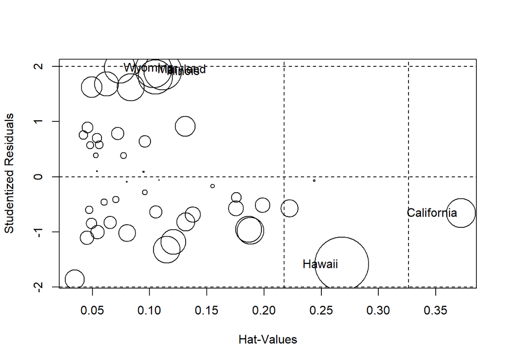

```
##               StudRes        Hat      CookD
## California -0.6558553 0.37199384 0.05167690
## Hawaii     -1.5838954 0.26775883 0.17696136
## Illinois    1.9174084 0.11139821 0.08653001
## Maryland    1.9451929 0.10360106 0.08190093
## Wyoming     1.9757198 0.07398509 0.05824946
```

```r
influencePlot(fit)
```

### 최선의 회귀모형 고르기

```
1. 수정된 결정계수
2. AIC 또는 BIC
3. mallows Cp
```

```r
require(leaps)
```

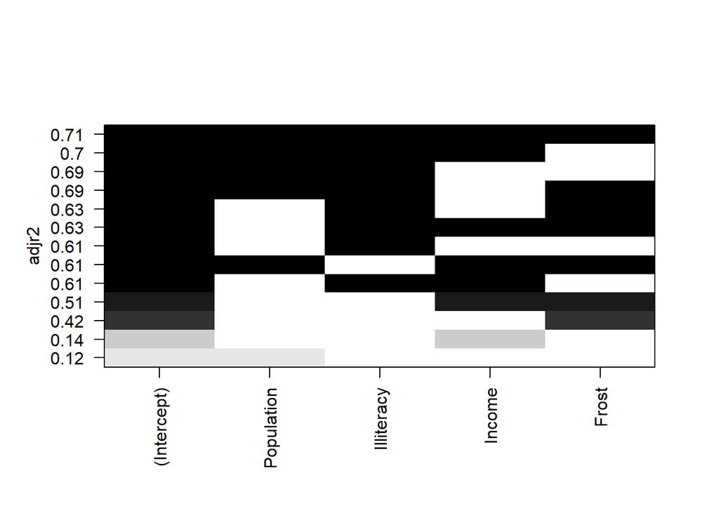

```r
leaps <-regsubsets(Murder ~ Population + Illiteracy + Income + Frost, data=newdata3, nbest=4)
plot(leaps, scale="adjr2")
```

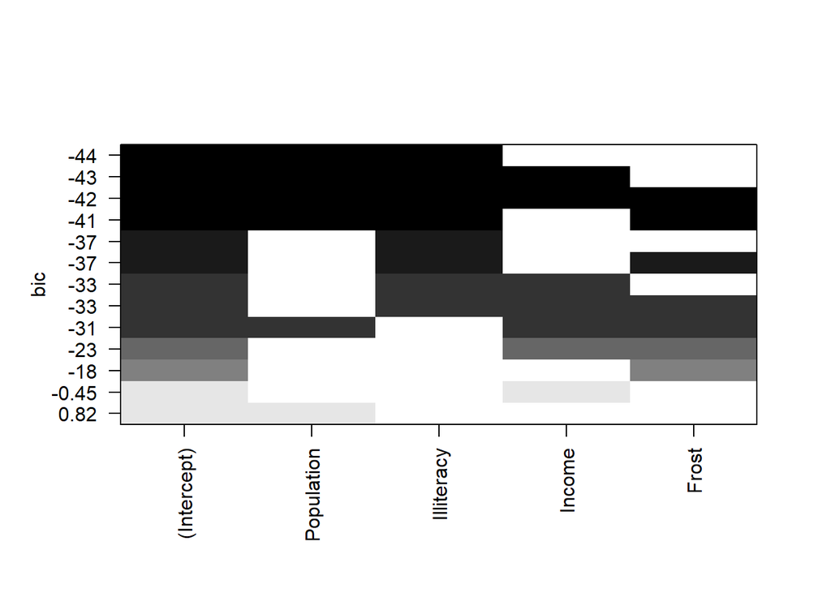

```r
plot(leaps, scale="bic")
```

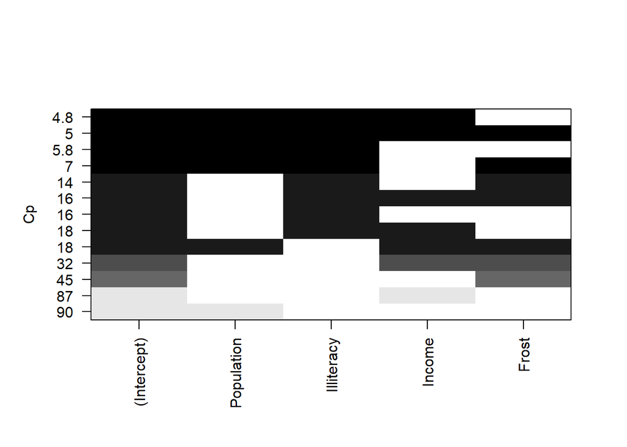

```r
plot(leaps, scale="Cp")
```

## 회귀모형의 일반화

### 교차검증(Cross-validatiaon)

단순히 회귀 모형을 고르고 해석하는 것이 목적이라면 그것으로 일이 끝난 것이겠지만 회귀분석의 목적이 예측이라면 “과연 이 회귀식이 실제 현실(real world)에서 얼마나 잘 들어맞을까?”하는 질문을 던지게 된다.

정의상, 회귀분석은 주어진 데이터셋에서 가장 알맞는 인자들을 골라낸다. 일반적인 OLS 회귀에서는 예측 에러의 제곱의 합(잔차)을 최소화하기 위해, 바꿔 말해 반응변수가 설명할수 있는 범위를 최대화하기 위해 인자들을 고른다. 회귀식은 주어진 데이터셋에 최적화되어 있기 때문에 다른 데이터에서는 주어진 데이터셋에 비해 제대로 작동 안 할 수도 있다.

예를 들어 한 운동생리학자가 운동에 따른 칼로리 소모를 예측하기 위해 운동의 강도와 운동시간, 나이, 성별, 그리고 체질량지수(Body-mass index)등의 인자들을 사용하여 회귀분석을 통해 회귀식을 얻었다고 하자. 이 회귀식은 주어진 데이터셋에서 수정된 결정계수를 최대화하는 모형이다. 하지만 연구자가 연구에 참여하지 않은 일반인의 칼로리 소모를 예측하기 위해 이 회귀식을 사용한다고 하면 우리는 새로운 샘플의 모형에서는 회귀식이 연구에 참여한 사람보다는 잘 들어맞지 않을 것이라는 것을 안다. 하지만 얼마나 들어맞지 않을 것인가?

> 교차검증(Cross-validation)은 회귀식의 일반화를 평가하는 데 유용한 방법이다.

```
교차검증에서는 데이터의 일부를 training sample로 사용하고 나머지는 hold-out sample로 사용한다. Training sample을 사용하여 회귀식을 만들고 이 회귀식을 hold-out sample에 적용해본다. Hold-out sample은 회귀모형의 인자 선택에 관여하지 않기 때문에 hold-out sample에서의 회귀식의 수행 능력은 새로운 데이터에서 회귀모형의 수행 능력을 평가하는 데 보다 정확한 방법이 될 것이다.

K-fold 교차검증에서는 smaple을 k개의 subsample로 나눈다. 각각의 k subsample을 hold-out group으로 사용하며 나머지 k-1 subsample을 training subsample로 사용한다. K 예측 공식을 k-hold out sample에 적용하여 평균을 낸다(k가 관측치의 총 개수(n)와 같을 때 이 방법은 jackknifing이라고 한다). R에서는 bootstrap 패키지에 있는 crossval() 함수를 사용하여 k-fold 교차검증을 수행할 수 있다. 다음 함수 shrinkage()는 주어진 회귀모형의 결정계수 값에 대한 cross-validation을 수행한다(이 함수는 Robert I. Kabacoff의 R in Action(2011)책에 공개되어 있는 함수이다).
```

```r
shrinkage <- function(fit, k=10){
  if(!require(bootstrap)) install.packages("bootstrap")

  library(bootstrap)

  theta.fit <- function(x,y){lsfit(x,y)}
  theta.predict <- function(fit,x){cbind(1,x)%*%fit$coef}

  x <- fit$model[,2:ncol(fit$model)]
  y <- fit$model[,1]

  results <- crossval(x, y, theta.fit, theta.predict, ngroup=k)
  r2 <- cor(y, fit$fitted.values)^2
  r2cv <- cor(y, results$cv.fit)^2
  cat("Original R-square =", r2, "\n")
  cat(k, "Fold Cross-Validated R-square =", r2cv, "\n")
  cat("Change =", r2-r2cv, "\n")
}
```

이 함수가 하는 일은 predictor와 predicted value의 행렬을 만들어 raw 결정계수와 cross-validated 결정계수를 구해준다.

```r
fit1=lm(Murder~.,data=states)
shrinkage(fit1)
```

```
## Original R-square = 0.5669502
## 10 Fold Cross-Validated R-square = 0.4697401
## Change = 0.0972101
```

위의 결과에서 이 회귀식의 $R^2$ 값 0.567은 너무나 낙관적이라는 것을 알 수 있다. 이 모형의 회귀식을 새로운 데이터에 적용했을 때 이 모형이 설명할 수 있는 $R^2$는 교차검증된 0.4697 정도일 것이다 (교차검증 시 관측치가 k개의 군으로 무작위 배정되기 때문에 shrinkage() 함수를 실행할 때마다 약간씩 다른 결과가 나올 것이다).

후진제거법을 이용한 변수 선택을 통해 선택된 회귀모형에 대해 실행해보자.

```r
full.model=lm(Murder~.,data=states)
reduced.model=step(full.model,direction="backward")
```

```
## Start:  AIC=97.75
## Murder ~ Population + Illiteracy + Income + Frost
##
##              Df Sum of Sq    RSS     AIC
## - Frost       1     0.021 289.19  95.753
## - Income      1     0.057 289.22  95.759
## <none>                    289.17  97.749
## - Population  1    39.238 328.41 102.111
## - Illiteracy  1   144.264 433.43 115.986
##
## Step:  AIC=95.75
## Murder ~ Population + Illiteracy + Income
##
##              Df Sum of Sq    RSS     AIC
## - Income      1     0.057 289.25  93.763
## <none>                    289.19  95.753
## - Population  1    43.658 332.85 100.783
## - Illiteracy  1   236.196 525.38 123.605
##
## Step:  AIC=93.76
## Murder ~ Population + Illiteracy
##
##              Df Sum of Sq    RSS     AIC
## <none>                    289.25  93.763
## - Population  1    48.517 337.76  99.516
## - Illiteracy  1   299.646 588.89 127.311
```

```r
shrinkage(reduced.model)
```

```
## Original R-square = 0.5668327
## 10 Fold Cross-Validated R-square = 0.506937
## Change = 0.05989572
```

모든 변수를 선택하는 것보다 중요한 변수만 선택하여 예측시 보다 안정적이고 정확한 예측이 가능함을 알 수 있다.

## 상대적 중요성

지금까지 우리는 어떤 변수들이 결과를 예측하는 데 유용한가 하는데 초점을 맞추어 왔다. 하지만 다룰 내용은 이들 변수들 중에 결과를 예측하는 데 가장 중요한 변수는 무엇인가 하는 것이다. 또한 이들 예측변수들의 상대적 중요성에 따라 순위를 매기는 것을 원할 수도 있다. 만일 예측인자들이 서로 상관관계가 없다면 이러한 일은 매우 쉬울 수 있다. 이때는 예측인자들과 반응변수 사이의 상관관계로써 순위를 매길 수 있을 것이다. 하지만 대부분의 경우에는 예측인자들이 서로 상관관계가 있기 때문에 상대적인 중요도의 순위를 매기는 일은 쉽지 않다.

```r
states <- as.data.frame(state.x77[,c("Murder", "Population",
                                 "Illiteracy", "Income", "Frost")])
zstates <- as.data.frame(scale(states))
zfit <- lm(Murder~Population + Income + Illiteracy + Frost, data=zstates)
coef(zfit)
```

```
##   (Intercept)    Population        Income    Illiteracy         Frost
## -2.054026e-16  2.705095e-01  1.072372e-02  6.840496e-01  8.185407e-03
```

결과를 보면 문맹률(Illiteracy)이 표준편차만큼 증가하면 인구수, 수입, 기온이 일정할 때 살인사건 발생률이 표준편차의 0.68배 증가하는 것을 알 수 있다. 표준화된 회귀계수를 사용하면 문맹률이 가장 중요한 예측인자이고 Frost가 가장 중요도가 떨어진다. 한편 이러한 상대적인 중요도를 정량화하려는 다른 많은 시도들이 있었다. 상대적인 중요도는 이들 각 예측인자들이 $R^2$에 기여하는 정도로 생각해볼 수 있다.

기존의 많은 접근방법들은 relaimpo 패키지에 포함되어 있다.

Relative weights라고 불리는 새로운 방법은 모든 가능한 submodel에서 한 예측변수를 추가하였을 때 평균적인 $R^2$의 증가를 보는 것으로 다음의 코드로 계산할 수 있다. 코드에 대한 자세한 설명은 생략한다. 하지만 코드에 대한 이해가 없어도 사용하는 데에는 지장이 없다.

```r
relweights <- function(fit,...){
         R <- cor(fit$model)
         nvar <- ncol(R)
         rxx <- R[2:nvar, 2:nvar]
         rxy <- R[2:nvar, 1]
         svd <- eigen(rxx)
         evec <- svd$vectors
         ev <- svd$values
         delta <- diag(sqrt(ev))
         lambda <- evec %*% delta %*% t(evec)
         lambdasq <- lambda ^ 2
         beta <- solve(lambda) %*% rxy
         rsquare <- colSums(beta ^ 2)
         rawwgt <- lambdasq %*% beta ^ 2
         import <- (rawwgt / rsquare) * 100
         import <- as.data.frame(import)
         row.names(import) <- names(fit$model[2:nvar])
         names(import) <- "Weights"
         import <- import[order(import),1, drop=FALSE]
         dotchart(import$Weights, labels=row.names(import),
            xlab="% of R-Square", pch=19,
            main="Relative Importance of Predictor Variables",
            sub=paste("Total R-Square=", round(rsquare, digits=3)),
            ...)
         return(import)
}
```

이 코드는 Dr. Johnson의 논문에 있는 SPSS 프로그램을 R로 바꾼 것으로 “R in action”책에 인용된 것을 다시 인용한 것이다. 자세한 설명은 Johnson(2000, Mutilvariate BehavioralResearch, 35,1-19)을 참조하면 된다.

실제 예로써 states데이터의 예측변수들의 상대적 중요도를 보는 방법은 다음과 같다.

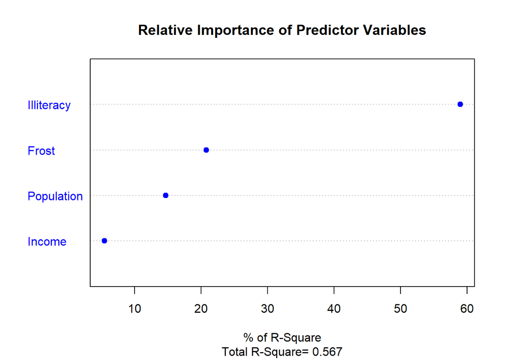

```
##              Weights
## Income      5.488962
## Population 14.723401
## Frost      20.787442
## Illiteracy 59.000195
```

```r
states <- as.data.frame(state.x77[,c("Murder", "Population",
                "Illiteracy", "Income", "Frost")])
fit <- lm(Murder ~ Population + Illiteracy + Income + Frost, data=states)
relweights(fit, col="blue")
```

이 회귀모형은 4개의 예측변수로 Murder의 전체 분산 중 56.7%를 설명해주고 있는데, 이 중 Illiteracy가 59%를 설명해주고 있으며 Frost가 20.79%를 설명해주고 있다. Relative weights 방법에 의하면 Illiteracy가 상대적인 중요도가 가장 크다. 이와 같은 relative weights에 의한 상대적인 중요성 개념은 표준화된 회귀계수에 비해 매우 직관적이기 때문에 향후 널리 사용될 것이 기대된다.